# Explore Bike Share Data

### Explore Bike Share Data

For this project, your goal is to ask and answer three questions about the available bikeshare data from Washington, Chicago, and New York. This notebook can be submitted directly through the workspace when you are confident in your results.

You will be graded against the project [Rubric](https://review.udacity.com/#!/rubrics/2508/view) by a mentor after you have submitted. To get you started, you can use the template below, but feel free to be creative in your solutions!

### Question 1

When looking at Chicago ONLY, what is the distribution of Customer trip durations in minutes?

```r
library(ggplot2)
chi  = read.csv('chicago.csv')
```

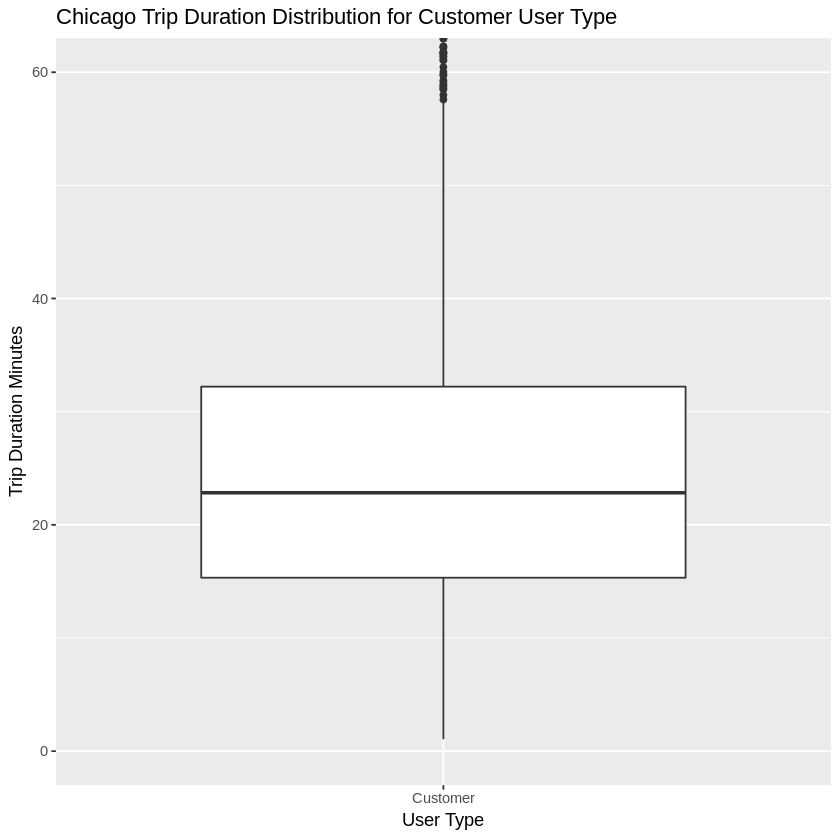

```r
ggplot(data = subset(chi, User.Type == "Customer"),
       aes(x = User.Type, y = Trip.Duration/60)) +
  geom_boxplot() +
  xlab("User Type") +
  ylab("Trip Duration Minutes") +
  labs(title = "Chicago Trip Duration Distribution for Customer User Type") +
  coord_cartesian(ylim = c(0,60))
```

**Summary of question 1: Customer users in Chicago appear to rent bicycles for durations bewteen 15 and 32 minutes. The median trip duration is roughly 22 minutes. This infers these users are going relatively short distances for this length of time. Possible scenarios could be commuting from one side of town to the other.**

### Question 2

Which city has the greatest volume of rentals?

```r
library(ggplot2)
library(plyr)
library(tidyverse)
library(dplyr)

ny = read.csv('new_york_city.csv')
wash = read.csv('washington.csv')
chi  = read.csv('chicago.csv')
```

```r
ny2<- cbind(ny[1:7], Location_name = "NYC")
wash2 <- cbind(wash[1:7], Location_name = "Washington")
chi2 <- cbind(chi[1:7], Location_name = "Chicago")
first_union = merge(ny2, wash2, all=TRUE)
second_union = merge(first_union, chi2, all=TRUE)
```

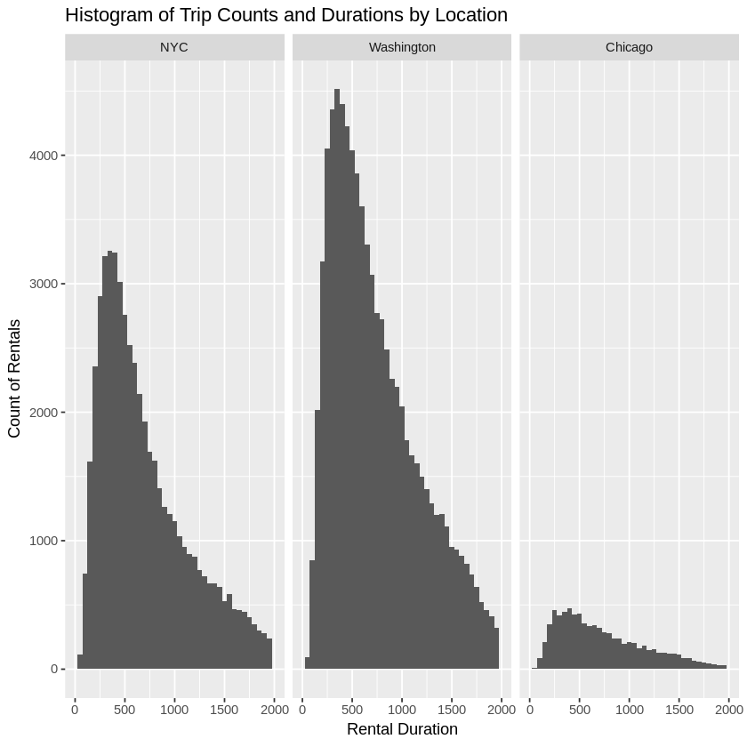

```r
ggplot(aes(x = Trip.Duration), data = second_union) +
  geom_histogram(binwidth = 50) +
  ggtitle("Histogram of Trip Counts and Durations by Location") +
  scale_x_continuous(limits = c(0, 2000), breaks = seq(0, 2000, 500)) +
  facet_wrap(~Location_name) +
  labs(x = "Rental Duration", y = "Count of Rentals")
```

**Summary of question 2: Based on the histograms provided, we see the largest volume spikes in Washington, with the max capping out over 4,500. Chicago data shows all of their rentals are under the 500 mark. While NYC does display a behavior pattern similar to Washington, the values are smaller. It may be possible the great number of rentals and durations in Washington are driven by vacation visitors and not necessarily locals, considering the amount of travelers who visit there annually.**

### Question 3

When looking at all locations combined, which location has the shortest trip duration?

```r
library(ggplot2)
library(plyr)
library(tidyverse)
library(dplyr)

ny = read.csv('new_york_city.csv')
wash = read.csv('washington.csv')
chi  = read.csv('chicago.csv')
```

```r
ny2<- cbind(ny[1:7], Location_name = "NYC")
wash2 <- cbind(wash[1:7], Location_name = "Washington")
chi2 <- cbind(chi[1:7], Location_name = "Chicago")
first_union = merge(ny2, wash2, all=TRUE)
second_union = merge(first_union, chi2, all=TRUE)
```

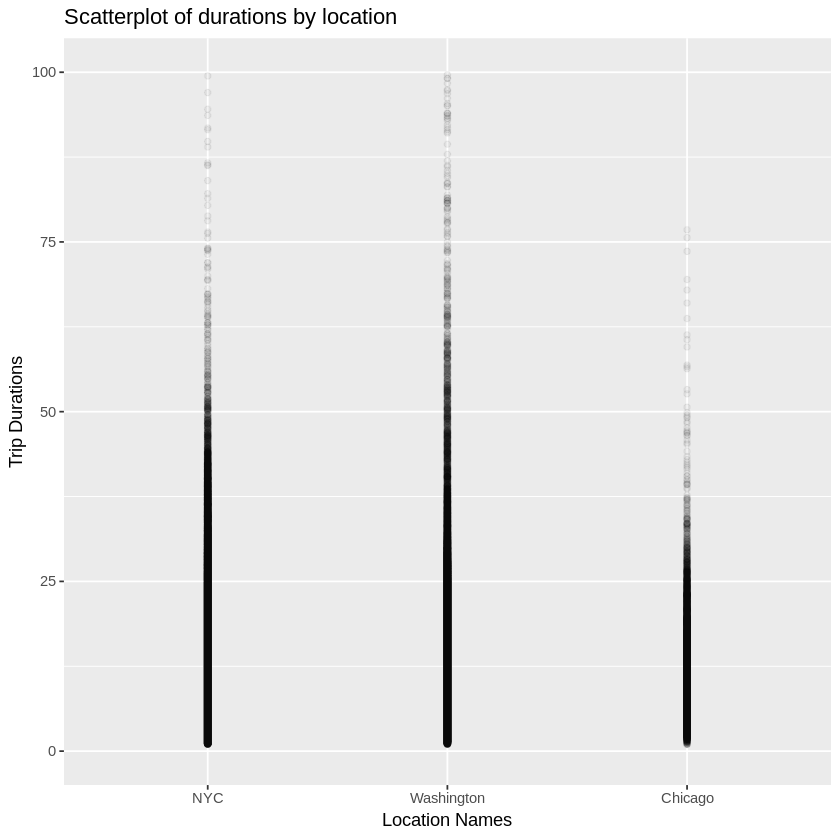

```r
ggplot(aes(x = Location_name, y = Trip.Duration/60), data = subset(second_union, User.Type == "Subscriber")) +
  geom_point(alpha = 1/20) +
  ylim(0, 100) +
  xlab("Location Names") +
  ylab("Trip Durations") +
  labs(title = "Scatterplot of durations by location")
```

**Summary of question 3: Using the scatterplot view by location and duration above, we see Chicago has the shortest trip durations, as evident with the shading of the column. It appears the majority of these rides are less than 40 minutes total. Could this be because the physical city itself is smaller in size than NYC and Washington? I am not surprised to see Washington has the greatest volume of longer rides, there is a lot to see and things are rather spread apart.**

## Directions to Submit

> Before you submit your project, you need to create a .html or .pdf version of this notebook in the workspace here. To do that, run the code cell below. If it worked correctly, you should get a return code of 0, and you should see the generated .html file in the workspace directory (click on the orange Jupyter icon in the upper left).

> Alternatively, you can download this report as .html via the **File** > **Download as** submenu, and then manually upload it into the workspace directory by clicking on the orange Jupyter icon in the upper left, then using the Upload button.

> Once you've done this, you can submit your project by clicking on the "Submit Project" button in the lower right here. This will create and submit a zip file with this .ipynb doc and the .html or .pdf version you created. Congratulations!

```r
system('python -m nbconvert Explore_bikeshare_data.ipynb')
```